# WHU Aerial data for external replication

Can WHU Aerial support an external replication of the RID initialization comparison? The analysis examines the prepared **0.3 m raster release**, binary target semantics, provider roles, class balance and spatial metadata. Qualitative examples use training and validation images only.

The [official dataset page](https://gpcv.whu.edu.cn/data/building_dataset.html) describes Christchurch aerial imagery and its LINZ source. The associated paper is Ji, Wei and Lu (2019), [doi:10.1109/TGRS.2018.2858817](https://doi.org/10.1109/TGRS.2018.2858817). File observations are distinguished from provider statements.

## Data identity and provider roles

The downloaded object is the provider's prepared 0.3 m archive with raster labels. It is distinct from the 0.2 m COCO product, both satellite products and the original large aerial mosaic. The provider publishes no trusted checksum for this archive, so the SHA-256 below is a locally computed byte identity rather than an authenticity proof.

The archive is paired strictly by filename within each supplied role. Missing or unexpected files stop preparation; nothing is silently repaired.

```python
from pathlib import Path
import pandas as pd
import matplotlib.pyplot as plt

from roofseg.integrity import load_json
from roofseg.whu_data import plot_provider_split_schematic, plot_whu_examples

ROOT = Path.cwd()
manifest = load_json(ROOT / "data/metadata/whu/data_manifest.json")
splits = load_json(ROOT / "data/metadata/whu/splits.json")
audit = load_json(ROOT / "reports/whu_data_audit.json")
```

```python
identity = pd.DataFrame({
    "field": ["Variant", "Archive bytes", "Local SHA-256", "Pairs", "Provider roles"],
    "observed value": [
        manifest["dataset"]["variant"], manifest["dataset"]["archive_bytes"],
        manifest["dataset"]["archive_sha256"], manifest["audit"]["pair_count"],
        str(splits["counts"]),
    ],
})
identity
```

|  | field | observed value |
| --- | --- | --- |
| 0 | Variant | prepared 0.3 m raster images and labels |
| 1 | Archive bytes | 5432920408 |
| 2 | Local SHA-256 | 62a4b4ef0fdfc98deee44b29fd0fe949554a928e1e9d38... |
| 3 | Pairs | 8188 |
| 4 | Provider roles | {'train': 4736, 'val': 1036, 'test': 2416} |

The role directories contain 4,736 training, 1,036 validation and 2,416 test pairs, or 8,188 pairs altogether. This agrees with the arithmetic printed on the provider page, although its surrounding prose states 8,189 tiles. The downloadable files and their role arithmetic are the operational contract; the discrepancy is retained in the manifest rather than concealed.

## Raster and target contract

Every file was opened and checked. Images must be 512 × 512, three-band `uint8` TIFFs; labels must be 512 × 512, one-band `uint8` TIFFs containing only 0 and 1. Development-pair inspection establishes the direction of this archive's binary code: all-one masks align with tiles containing no buildings, while zero-valued regions align with visible building footprints. The model target is therefore `mask == 0`.

This target differs conceptually from RID. WHU rasterizes edited **building footprints** across ordinary map tiles. RID supplies roof-centred samples and codes visible **roof segments**. A future comparison can replicate an initialization contrast, but it cannot make annotation effort or target semantics identical.

```python
contract = pd.DataFrame({
    "property": ["Image shape", "Mask shape", "Image dtype/range", "Mask values",
                 "Binary target", "CRS", "Physical pixel size in TIFF", "Invalid pixels"],
    "verified value": [
        manifest["audit"]["image_shapes_chw"], manifest["audit"]["mask_shapes_chw"],
        f"{manifest['audit']['image_dtypes']}, {manifest['audit']['image_value_range']}",
        manifest["audit"]["mask_values_observed"], "mask == 0", manifest["audit"]["crs_values"],
        "absent; 0.3 m is provider documentation", not manifest["audit"]["all_pixels_valid_by_file_mask"],
    ],
})
contract
```

|  | property | verified value |
| --- | --- | --- |
| 0 | Image shape | [[3, 512, 512]] |
| 1 | Mask shape | [[1, 512, 512]] |
| 2 | Image dtype/range | ['uint8'], [0, 255] |
| 3 | Mask values | [0, 1] |
| 4 | Binary target | mask == 0 |
| 5 | CRS | [None] |
| 6 | Physical pixel size in TIFF | absent; 0.3 m is provider documentation |
| 7 | Invalid pixels | False |

The prepared TIFFs have no CRS, non-identity physical transform, ground-control points or nodata declaration. Their identity transform is a pixel-index convention, not a one-metre georeference. All dataset-mask pixels are valid, so future loss and metrics need no WHU-specific validity mask unless later preprocessing introduces padding.

## Development examples

The following examples are selected deterministically from training and validation metadata by building-area criteria: a typical non-empty training tile, a sparse validation target near its positive 10th percentile, the densest validation target, and an empty target. This exposes both ordinary and difficult class-balance cases without looking at test imagery. Red overlays denote the binary building target.

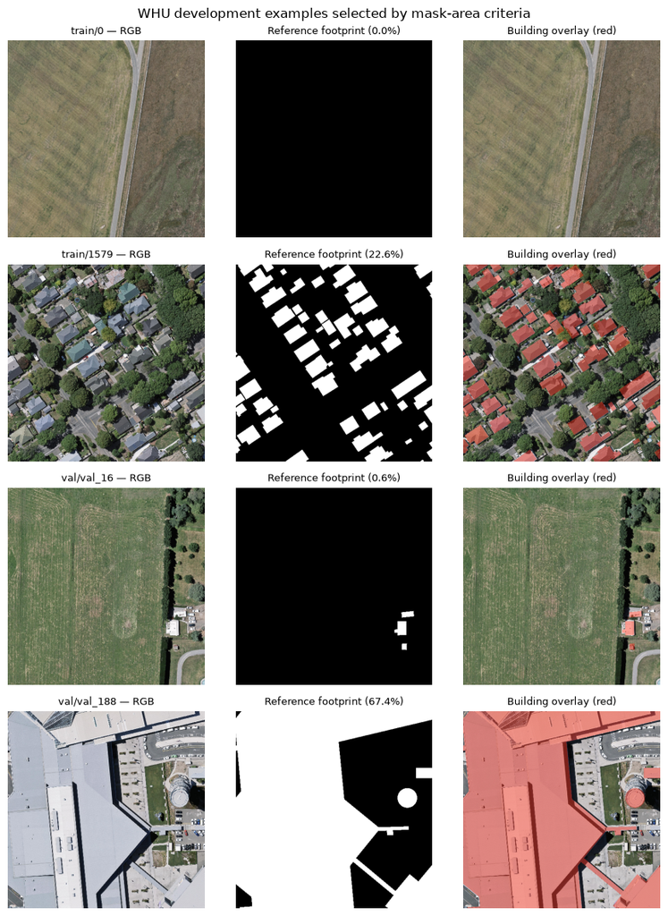

```python
figure = plot_whu_examples(manifest, ROOT)
figure_path = ROOT / "reports/figures/06_whu_development_examples.png"
figure_path.parent.mkdir(parents=True, exist_ok=True)
figure.savefig(figure_path, dpi=160, bbox_inches="tight")
plt.show()
```

The examples show that the mask geometry follows building footprints rather than RID's roof-segment taxonomy. Empty and very sparse tiles are legitimate background cases, not missing labels. They must remain in training and evaluation, with the empty-target metric convention stated before any pilot.

## Completeness, class balance and exact duplicates

The audit reports mask area by provider role and hashes each image and label. Repeated empty masks are expected byte duplicates and do not imply repeated scenery; exact image duplicates and exact image–mask pair duplicates are stronger leakage signals. Only aggregate test-role statistics are used for this technical audit, never test imagery or per-tile examples.

```python
role_summary = pd.DataFrame(audit["role_summaries"]).T
role_summary.index.name = "provider role"
role_summary.style.format({
    "minimum": "{:.3%}", "median": "{:.3%}",
    "mean": "{:.3%}", "maximum": "{:.3%}",
})
```

| provider role | count | empty_masks | minimum | median | mean | maximum |
| --- | --- | --- | --- | --- | --- | --- |
| train | 4736.000000 | 419.000000 | 0.000% | 21.585% | 18.664% | 71.774% |
| val | 1036.000000 | 299.000000 | 0.000% | 4.079% | 11.000% | 67.397% |
| test | 2416.000000 | 685.000000 | 0.000% | 6.343% | 11.128% | 78.877% |

```python
duplicate_summary = pd.DataFrame({
    "groups": audit["duplicate_group_counts"],
    "members per group": {
        key: str(value) for key, value in audit["duplicate_group_sizes"].items()
    },
})
duplicate_summary
```

|  | groups | members per group |
| --- | --- | --- |
| exact_duplicate_image_groups | 0 | [] |
| exact_duplicate_mask_groups | 1 | [1403] |
| exact_duplicate_pair_groups | 0 | [] |
| cross_role_duplicate_image_groups | 0 | [] |
| cross_role_duplicate_pair_groups | 0 | [] |

The pairing audit found no missing role member because preparation would fail before writing these records. There is one repeated-mask group containing all 1,403 empty masks and no other mask; identical all-background rasters are expected and do not imply repeated scenery. No image or complete image–mask pair is byte-identical, either within or across roles. Hash equality cannot detect shifted, resampled or otherwise near-duplicate views.

## What can be verified about geographic separation?

The provider documents one 64 × 74 training block, one 14 × 74 evaluation block, and two test blocks of 17 × 42 and 23 × 74 tiles. Its map depicts separate source areas. The schematic below preserves only those stated dimensions; it deliberately does not invent relative coordinates from filenames.

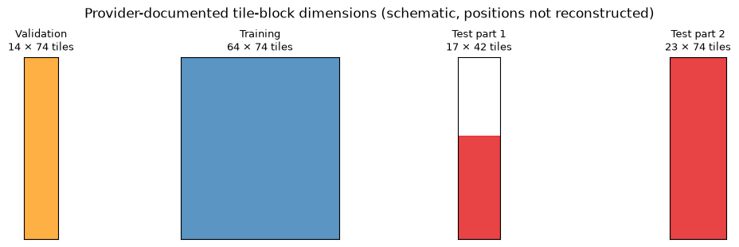

```python
figure = plot_provider_split_schematic()
split_path = ROOT / "reports/figures/06_whu_provider_split_schematic.png"
figure.savefig(split_path, dpi=160, bbox_inches="tight")
plt.show()
```

```python
spatial_checks = pd.Series({
    "Embedded georeferencing": splits["spatial_audit"]["embedded_georeferencing"],
    "Per-tile coordinates": splits["spatial_audit"]["per_tile_coordinates_available"],
    "Numeric order treated as coordinates": splits["spatial_audit"]["numeric_order_used_as_coordinates"],
    "Cross-role exact image duplicates": splits["spatial_audit"]["exact_cross_role_image_duplicates"],
    "Cross-role exact pair duplicates": splits["spatial_audit"]["exact_cross_role_pair_duplicates"],
}, name="verified value").to_frame()
spatial_checks
```

|  | verified value |
| --- | --- |
| Embedded georeferencing | False |
| Per-tile coordinates | False |
| Numeric order treated as coordinates | False |
| Cross-role exact image duplicates | 0 |
| Cross-role exact pair duplicates | 0 |

**Verified finding and limitation.** The provider roles are distinct file sets, and exact cross-role image/pair hashes are checked. However, the prepared release does not expose physical tile footprints. The documented region layout supports retaining the provider split, but complete visible-area overlap cannot be recomputed independently. The statement that crop order can recover the mosaic is insufficient to assume a particular row/column convention or global placement without an explicit index map.

This also prevents a defensible spatial-maximin sample selection. Numeric names remain identifiers only.

## Sampling design

Uniform random sampling selects 100 training IDs using a NumPy generator with seed 17, without reference to labels or model results. Validation uses the provider validation role. Physical tile coordinates are unavailable, so the spatial-maximin design used for RID cannot be reproduced defensibly on this release.

```python
pilot = splits["future_pilot_subset"]
pilot_checks = pd.Series({
    "Stored IDs": len(pilot["ids"]),
    "Unique IDs": len(set(pilot["ids"])),
    "All belong to training": set(pilot["ids"]) <= set(splits["roles"]["train"]),
    "Overlap with validation": len(set(pilot["ids"]) & set(splits["roles"]["val"])),
    "Overlap with test": len(set(pilot["ids"]) & set(splits["roles"]["test"])),
    "Subset seed": pilot["seed"],
}, name="value").to_frame()
pilot_checks
```

|  | value |
| --- | --- |
| Stored IDs | 100 |
| Unique IDs | 100 |
| All belong to training | True |
| Overlap with validation | 0 |
| Overlap with test | 0 |
| Subset seed | 17 |

## Conclusion

The prepared WHU release provides reproducible image–mask pairing, a binary building-footprint target and defined provider roles. Its target semantics, spatial resolution and empty-image frequency differ from RID, so replication concerns the initialization contrast rather than equal annotation effort or directly comparable absolute scores.

The principal limitation is missing spatial metadata: provider-area separation can be documented, but tile-footprint overlap cannot be independently reconstructed. The provider split is retained and uniform sampling is used. Notebook 7 reports the paired initialization experiments.